# 4 **Chemical Composition of Cells**

## 4.1 **Pre-Lab Activity 4.1: Questions**

**Pre-Lab Questions (7 pts)**

Complete these questions before coming to lab. They are designed to prepare you for the laboratory procedures and concepts

**Multiple Choice (0.5 pt each)**

**1. Which of the following is a monosaccharide?**

A. Sucrose  
B. Lactose  
C. Glucose  
D. Starch

**2. Benedict's reagent is used to detect the presence of:**

A. Proteins  
B. Lipids  
C. Reducing sugars  
D. Starch

**3. Which reagent is used to detect proteins?**

A. Iodine  
B. Sudan III  
C. Biuret  
D. Benedict's

**4. Which carbohydrate serves as the primary storage polysaccharide in plants?**

A. Glycogen  
B. Cellulose  
C. Chitin  
D. Starch

**5. Which statement best describes a qualitative test?**

A. It determines the exact concentration of a substance.  
B. It measures molecular weight.  
C. It indicates whether a substance is present or absent.  
D. It determines the pH of a solution.

**6. Which reagent is used to detect starch?**

A. Iodine  
B. Sudan III  
C. Biuret  
D. Benedict's

**Short Answer (4 pts total)**

6. Explain the structural difference between monosaccharides, disaccharides, and polysaccharides. (2 pts)

7. What is the purpose of including positive and negative controls in a laboratory experiment? (2 pts)

## 4.2 **Learning Objectives**

Upon completion of this laboratory exercise, students will be able to:

1. Identify the four major classes of biological macromolecules found in living cells.
2. Differentiate between monosaccharides, disaccharides, and polysaccharides based on their chemical structure and biological function.
3. Describe the structure and function of proteins, amino acids, and lipids.
4. Distinguish between saturated and unsaturated fatty acids.
5. Explain the chemical principles behind qualitative tests used to detect carbohydrates, proteins, and lipids.
6. Perform Benedict's, iodine, Biuret, and Sudan III tests safely and accurately.
7. Interpret positive and negative test results using appropriate experimental controls.
8. Differentiate between qualitative and quantitative laboratory analyses.
9. Analyze experimental data to identify the major biological molecules present in unknown samples.

## 4.3 **Introduction**

All living organisms are composed of chemical compounds that perform essential functions needed for life. The majority of these compounds belong to four major classes of biological macromolecules:

- Carbohydrates
- Proteins
- Lipids
- Nucleic acids

In this laboratory exercise, you will examine three of these macromolecules—**carbohydrates**, **proteins**, and **lipids**—using chemical indicator tests. These tests allow scientists to identify specific types of molecules based on observable color changes or staining patterns. Although these laboratory tests do not determine the exact concentration of a substance, they provide valuable information about whether a particular biological molecule is present in a sample.

## 4.4 **Carbohydrates**

Carbohydrates are organic molecules composed primarily of carbon (C), hydrogen (H), and oxygen (O), generally in a ratio of approximately 1:2:1.

They serve several important biological functions including:

- Immediate energy source
- Energy storage
- Structural support
- Cell recognition

Carbohydrates are classified according to the number of sugar units they contain.

### 4.4.1 **Monosaccharides**

Monosaccharides are the simplest carbohydrates because they consist of a single sugar molecule.

Examples include:

- Glucose
- Fructose
- Galactose

Although glucose, galactose, and fructose all have the same chemical formula (C6H12O6), they differ structurally and chemically (and are isomers) because of the different arrangement of functional groups around the asymmetric carbon.

The chemical formula for glucose is C<sub>6</sub>H<sub>12</sub>O<sub>6</sub>. In humans, glucose is an important source of energy. During cellular respiration, energy is released from glucose, and that energy helps make adenosine triphosphate (ATP).

Galactose (part of lactose, or milk sugar) and fructose (found in sucrose, in fruit) are other common monosaccharides.

Monosaccharides are considered **reducing sugars**, meaning they possess a free aldehyde or ketone group capable of reducing certain chemical reagents such as Benedict's reagent.

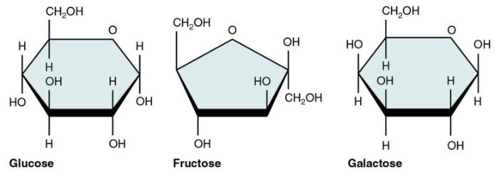

*Image Source: https://pressbooks.bccampus.ca/kinsnew/chapter/2-5-organic-compounds-essential-to-human-functioning-anatomy-and-physiology-2/*

### 4.4.2 **Disaccharides**

Disaccharides are formed when two monosaccharides join together through a dehydration synthesis reaction, creating a glycosidic bond.

Examples include:

| **Disaccharide** | **Composed of** |
| --- | --- |
| Maltose | Glucose + Glucose |
| Lactose | Glucose + Galactose |
| Sucrose | Glucose + Fructose |

Some disaccharides (maltose and lactose) are reducing sugars, whereas sucrose is considered a non-reducing sugar because its reactive groups are involved in the glycosidic bond.

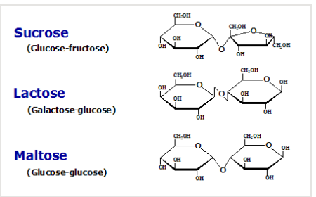

Image source: microbe notes [Monosaccharides, Disaccharides, and Polysaccharides](https://microbenotes.com/carbohydrates/)

### 4.4.3 **Polysaccharides**

Polysaccharides consist of hundreds or thousands of monosaccharides linked together.

Major examples include:

#### 4.4.3.1 **Starch**

- Plant energy storage molecules
- Composed of glucose
- Digestible by humans

#### 4.4.3.2 **Glycogen**

- Animal energy storage molecules
- Highly branched
- Stored in liver and muscle cells

#### 4.4.3.3 **Cellulose**

- Structural component of plant cell walls
- Humans cannot digest cellulose because we lack cellulase

Unlike monosaccharides, polysaccharides are generally not reducing sugars.

## 4.5 **Proteins**

Proteins are large biological molecules composed of amino acids linked together by peptide bonds.

Proteins perform a tremendous variety of cellular functions including:

- Enzymes
- Structural support
- Transport
- Hormones
- Cell signaling
- Immune defense
- Muscle contraction

Protein function depends upon its unique three-dimensional structure.

### 4.5.1 **Amino Acids**

Amino acids are the building blocks of proteins.

Each amino acid contains:

- Amino group (-NH₂)
- Carboxyl group (-COOH)
- Hydrogen atom
- Variable R-group (side chain)

Twenty different amino acids are commonly used to construct proteins.

Differences in their side chains determine the chemical properties and function of proteins.

## 4.6 **Lipids**

Lipids are hydrophobic molecules composed primarily of carbon and hydrogen.

Unlike carbohydrates, lipids contain relatively little oxygen.

Major functions include:

- Long-term energy storage
- Cell membrane structure
- Hormone production
- Thermal insulation
- Cushioning organs

Common classes of lipids include:

- Fats
- Oils
- Phospholipids
- Steroids
- Waxes

### 4.6.1 **Fatty Acids**

Most fats consist of glycerol attached to three fatty acids forming triglycerides.

Fatty acids differ in the presence or absence of double bonds.

#### 4.6.1.1 **Saturated Fatty Acids**

Saturated fatty acids contain **only single carbon-carbon bonds**.

Characteristics:

- Straight hydrocarbon chains
- Pack tightly together
- Usually solid at room temperature

Examples:

- Butter
- Lard
- Coconut oil

Excessive dietary intake is associated with increased cardiovascular disease risk.

#### 4.6.1.2 **Unsaturated Fatty Acids**

Unsaturated fatty acids contain **one or more carbon-carbon double bonds**.

These double bonds introduce bends (kinks) into the fatty acid chain.

Characteristics:

- Do not pack tightly
- Usually liquid at room temperature

Examples:

- Olive oil
- Canola oil
- Fish oil

Unsaturated fats are generally considered healthier dietary fats.

[figure not shown]

Image source [2.5.2: Lipid Molecules - Biology LibreTexts](https://bio.libretexts.org/Bookshelves/Microbiology/Microbiology_%28Boundless%29/02%3A_Chemistry/2.05%3A_Organic_Compounds/2.5.02%3A_Lipid_Molecules)

## 4.7 **Qualitative versus Quantitative Tests**

Scientists use different laboratory methods depending on the information they need.

### 4.7.1 **Qualitative Tests**

Qualitative tests determine whether a substance is present or absent.

Results are based on observations such as:

- Color change
- Precipitate formation
- Layer formation
- Staining

Example:

Benedict's test indicates whether reducing sugars are present.

This laboratory uses **qualitative testing**.

### 4.7.2 **Quantitative Tests**

Quantitative tests determine **how much** of a substance is present.

Results are numerical and often require specialized equipment such as:

- Spectrophotometers
- Colorimeters
- Analytical balances

Examples include:

- Blood glucose measurements
- Protein concentration assays
- Cholesterol analysis

## 4.8 **Experimental Controls**

Controls are essential components of every scientific experiment because they ensure that results are reliable and meaningful.

### 4.8.1 **Positive Control**

A positive control contains a substance known to produce the expected positive result.

Example:

Glucose solution serves as the positive control for Benedict's test because glucose is reducing sugar.

A successful positive control confirms that:

- The reagent is functioning properly
- The procedure was performed correctly

### 4.8.2 **Negative Control**

Negative control lacks the substance being tested.

Distilled water is commonly used.

Negative control should produce **no reaction**.

It confirms that:

- Positive results are due to the sample rather than contamination or reagent error.

## 4.9 **Laboratory Procedures: Chemical Composition of Cells**

**Safety Precautions**

- Wear safety goggles, gloves, and a lab coat throughout the experiment.
- Handle all reagents carefully. Sudan III is flammable and can stain skin and clothing.
- Benedict's reagent and Biuret reagent contain copper compounds that should not be ingested.
- Use caution when working with hot water baths.
- Dispose of chemical waste as instructed by your instructor.

Wash your hands before leaving the laboratory.

### 4.9.1 **Materials**

**Reagents**

- Benedict's reagent
- Lugol's iodine solution
- Biuret reagent
- Sudan III solution

**Equipment**

- Test tubes
- Test tube rack
- Test tube holder
- Graduated pipettes or transfer pipettes
- Hot water bath (95–100°C)
- Beakers
- Permanent marker
- Paper towels

### 4.9.2 **Part I. Chemical Indicator Tests - Benedict’s Test for Reducing Sugars**

**Principle**

Benedict's reagent detects reducing sugars containing free aldehyde or ketone groups.

When heated, reducing sugars reduce copper (II) ions (Cu²⁺) to copper (I) oxide (Cu₂O), producing a colored precipitate.

**Positive Results**

[output not shown]

**Negative Result -** Blue

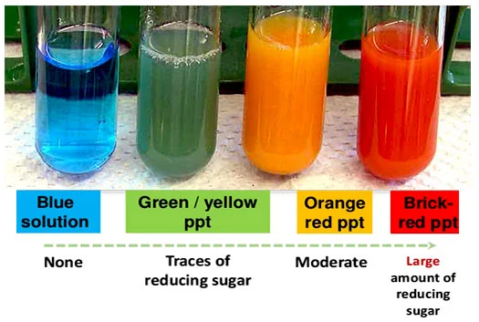

Image source: microbiology information.com [Benedict's Test- Principle, Preparation, Procedure and Result Interpretation](https://microbiologyinfo.com/benedicts-test-principle-composition-preparation-procedure-and-result-interpretation/)

**Procedure**

A. Label Six clean test tubes:

> 1. Positive Control (Glucose)

> 2. Negative Control (Water)

> 3. Onion

> 4. Potato

> 5. Grape juice

> 6. Unknown Sample
1. Add 2 mL of each sample into the appropriately labeled tube.
2. Add 1-2 mL of Benedict's reagent to each tube.
3. Mix gently.
4. Place the tubes in a beaker with water, place beaker on a hot plate and heat to boiling (95–100°C) for 3–5 minutes.
5. Carefully remove the tubes using a test tube holder.
6. Allow the tubes to cool for approximately 2 minutes.
7. Record your results in the Table.

Table 1: Benedicts test for reducing sugars

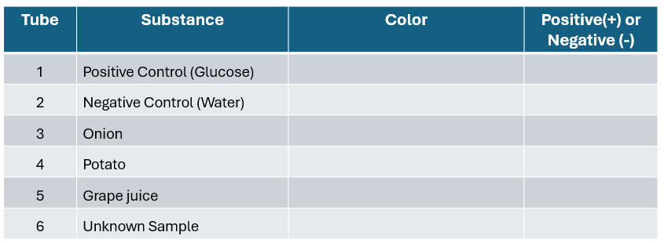

### 4.9.3 **Part II. Iodine Test for Starch**

**Principle**

Iodine molecules become trapped inside the helical structure of amylose, producing a dark blue-black color.

**Procedure**

1. Label Five clean test tubes:

> 1. Positive Control (Starch)

> 2. Negative Control (Water)

> 3. Onion

> 4. Potato

> 5. Unknown Sample
2. Add 2 mL of each sample.
3. Add 2–3 drops of Lugol's iodine solution.
4. Gently swirl the tube.
5. Observe immediately.
6. Record your results in the table.

| **Color** | **Interpretation** |
| --- | --- |
| Yellow-Brown | Negative |
| Blue-Black | Positive for starch |

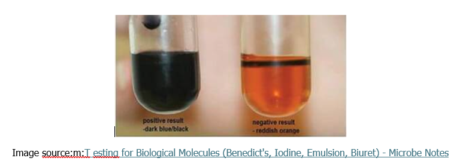

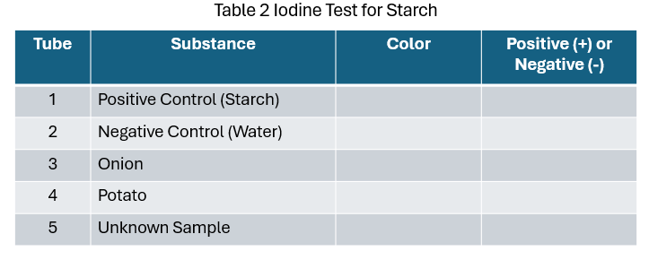

### 4.9.4 **Part III. Biuret Test for Proteins**

**Principle**

Copper ions in Biuret reagent react with peptide bonds in proteins under alkaline conditions to form a violet-colored complex.

**Procedure**

> 1. Positive Control (Egg albumin)

> 2. Negative Control (Water)

> 3. Chicken broth

> 4. Milk

> 5. Unknown Sample
2. Add 2 mL of each sample.
3. Add 2 mL of Biuret reagent.
4. Mix gently.
5. Allow the tubes to stand for 2–3 minutes.
6. Record results in table.

**Biuret Test Results**

| **Color** | **Interpretation** |
| --- | --- |
| Blue | Negative |
| Violet/Purple | Positive for protein |

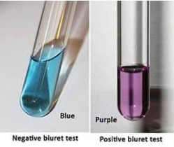

Image source:m:[T esting for Biological Molecules (Benedict's, Iodine, Emulsion, Biuret) - Microbe Notes](https://microbenotes.com/testing-for-biological-molecules/)

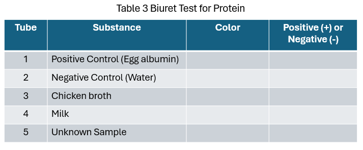

### 4.9.5 **Part IV. Sudan III Test for Lipids**

**Principle**

The Sudan III test is a qualitative test used to detect the presence of lipids (fats and oils). Sudan III is a fat-soluble dye that dissolves in lipids rather than water. When lipids are present on filter paper, the dye is retained in the lipid-containing area, producing a red to orange-red stained spot.

**Materials**

- Filter paper
- Pencil
- Forceps
- Cotton swabs
- Sudan III solution
- Distilled water (negative control)
- Vegetable oil (positive control)
- Test samples
- Petri dish or staining tray
- Wash bottle containing distilled water

**Procedure**

1. Place a piece of filter paper in a clean Petri dish or on a clean surface.
2. Using a pencil, draw and label circles (approximately 1–2 cm in diameter) for each sample.
3. Add 1–2 drops of each sample into its designated circle using cotton swabs.
4. Include:

> 1. Positive control (Vegetable oil)

> 2. Negative control (Distilled water)

> 3. Coconut milk (juice)

> 4. Whole milk

> 5. Skim milk

> 6. Italian dressing

> 6. Fat-free Italian dressing

> 7. Unknown
5. Allow the samples to air dry completely (approximately 10–15 minutes).
6. Pour enough Sudan III solution into a Petri dish to cover the filter paper.
7. Place the dried filter paper into the Sudan III solution for 3–5 minutes.
8. Remove the filter paper using forceps.
9. Rinse gently with distilled water for about 30–60 seconds to remove excess stain.
10. Use a blow dryer to dry filter paper briefly.
11. Observe and record the color of each spot, record results in table.

**Results**

| **Observation** | **Interpretation** |
| --- | --- |
| Bright orange-red or red stained spot remains | Positive for lipids |
| Little or no red/orange staining | Negative for lipids |

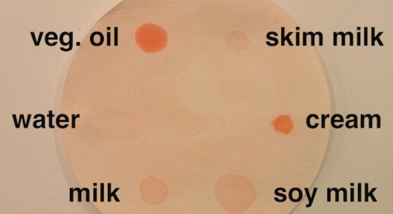

Image Source: [A Biology Laboratory Exercise Using Macromolecule Assays to Distinguish Four Types of Milk - PMC](https://pmc.ncbi.nlm.nih.gov/articles/PMC3577220/)

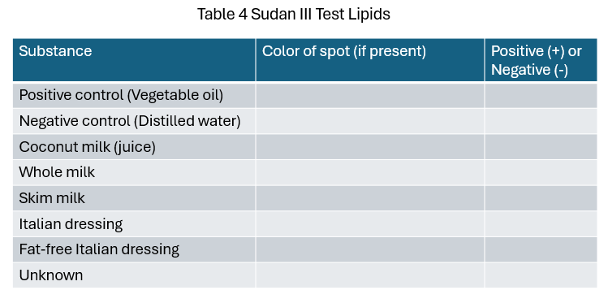

### 4.9.6 **Unknown Solution Identification**

After completing the previous experiments, you should have developed a working knowledge of qualitative tests used to identify the major classes of biological molecules, including simple sugars, starch, proteins, and lipids. In this exercise, you will apply those techniques to identify an unknown solution.

Each laboratory group will be assigned one unknown sample selected from a set of three possible solutions. Using the appropriate qualitative tests and comparing your results with the expected reactions of known substances, you will determine the identity of your assigned unknown. Be sure to record all observations carefully and use your test results as evidence to support your final identification.

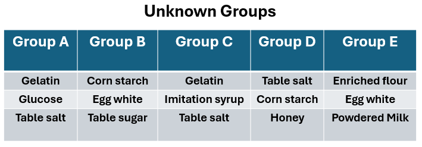

**Assigned Unknown Group:** ________________________________

**Instructions**

Complete **Table 5** by recording the expected results for each qualitative test and indicating the type of biological molecule that each test detects (the first row has been completed as an example). Use the information and results from **Table 7** to help you complete the table accurately.

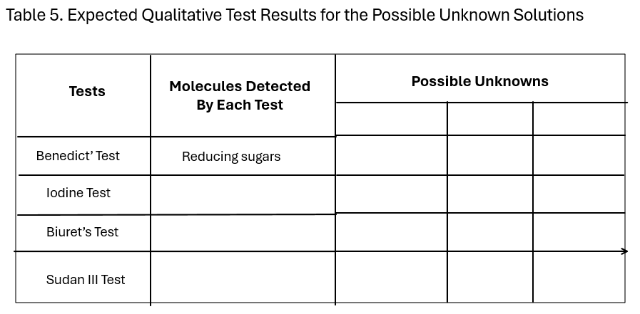

After completing **Table 5**, transfer your experimental results from **Tables 1–4** into **Table 6**. Compare your observed results with the expected results listed in **Table 5** for the possible unknown solutions. Use this comparison to determine the identity of your assigned unknown sample and record your conclusion in **Table 6**.

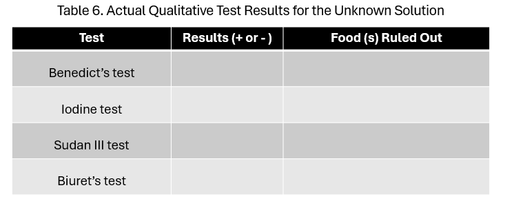

**Identity of the Unknown Solution:** _________________________

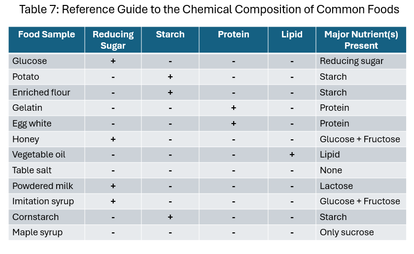

This reference table can be used by students to predict qualitative test results and compare them with their experimental observations during food composition analysis and unknown identification exercises.

### 4.9.7 **Cleanup**

1. Dispose of all chemical waste in the designated waste containers.
2. Thoroughly rinse test tubes with tap water followed by distilled water.
3. Return all equipment to the designated area.
4. Clean your workspace with a disinfectant if instructed.
5. Remove gloves and wash your hands thoroughly before leaving the laboratory.

### 4.9.8 **Scientific Significance**

Chemical indicator tests provide a rapid method for identifying biological molecules in foods, biological samples, and laboratory specimens. These qualitative assays are widely used in biology, biochemistry, medicine, food science, microbiology, and environmental science. Understanding how these tests work reinforces the relationship between molecular structure and biological function while introducing students to the principles of experimental design, including the use of controls, observation, and data interpretation. This laboratory also emphasizes that while qualitative tests identify the presence of a molecule, quantitative methods are required to accurately measure its concentration in research and clinical settings.

## 4.10 **Lab Worksheet: Pre-Lab and Post-Lab Questions**

Complete these questions before coming to lab. They are designed to prepare you for the laboratory procedures and concepts.

**Multiple Choice (0.5 pt each)**

**1. Which of the following is a monosaccharide?**

A. Sucrose  
B. Lactose  
C. Glucose  
D. Starch

**2. Benedict's reagent is used to detect the presence of:**

A. Proteins  
B. Lipids  
C. Reducing sugars  
D. Starch

**3. Which carbohydrate serves as the primary storage polysaccharide in plants?**

A. Glycogen  
B. Cellulose  
C. Chitin  
D. Starch

**4. Which statement best describes a qualitative test?**

A. It determines the exact concentration of a substance.  
B. It measures molecular weight.  
C. It indicates whether a substance is present or absent.  
D. It determines the pH of a solution.

**5.** Explain the structural difference between monosaccharides, disaccharides, and polysaccharides. (2 pts)

**6.** What is the purpose of including positive and negative controls in a laboratory experiment? (2 pts)

**Post-Lab Questions (15 pts)**

These questions require you to analyze your results and apply the concepts learned during the laboratory exercise.

**Part I: Data Interpretation (5 pts)**

**1. Unknown Sample Analysis (2 pts)**

An unknown sample produced the following results:

| **Test** | **Result** |
| --- | --- |
| Benedict's | Brick-red |
| Iodine | Negative |
| Biuret | Negative |
| Sudan III | Negative |

**a. Which biological molecule is present? ______________________**

**b. What evidence supports your conclusion? ___________________**

**2. Unknown Sample Analysis (3 pts)**

Another unknown sample produced these results:

| **Test** | **Result** |
| --- | --- |
| Benedict's | Negative |
| Iodine | Blue-black |
| Biuret | Negative |
| Sudan III | Negative |

**a. Identify the biological molecule present. ______________________**

**b. Explain why Benedict's test was negative while iodine was positive.**

A nutrition scientist analyzes two food samples.

- Sample A is positive for Sudan III but negative for Benedict's.
- Sample B is positive for Benedict's but negative for Sudan III.

**Compare the composition of the two samples and explain which would provide immediate energy and which would serve as long-term energy storage.**